# House Price Prediction using Linear Regression

## Internship Task 1

This project uses the California Housing dataset to build and evaluate a Linear Regression model.  
The workflow includes:

- Data loading
- Exploratory Data Analysis (EDA)
- Preprocessing
- Train-test split
- Model training
- Evaluation using MAE, RMSE, and R²
- Visualization of results

```python
import pandas as pd
import numpy as np
import matplotlib.pyplot as plt
import seaborn as sns
import joblib

from sklearn.datasets import fetch_california_housing
from sklearn.model_selection import train_test_split
from sklearn.linear_model import LinearRegression
from sklearn.metrics import mean_absolute_error, mean_squared_error, r2_score

sns.set(style="whitegrid")
```

## 1. Load the Dataset

The California Housing dataset is loaded from scikit-learn.  
It contains housing-related features and the target variable `MedHouseVal`.

```python
data = fetch_california_housing(as_frame=True)
df = pd.concat([data.data, data.target.rename("MedHouseVal")], axis=1)

df.head()
```

|  | MedInc | HouseAge | AveRooms | AveBedrms | Population | AveOccup | Latitude | Longitude | MedHouseVal |
| --- | --- | --- | --- | --- | --- | --- | --- | --- | --- |
| 0 | 8.3252 | 41.0 | 6.984127 | 1.023810 | 322.0 | 2.555556 | 37.88 | -122.23 | 4.526 |
| 1 | 8.3014 | 21.0 | 6.238137 | 0.971880 | 2401.0 | 2.109842 | 37.86 | -122.22 | 3.585 |
| 2 | 7.2574 | 52.0 | 8.288136 | 1.073446 | 496.0 | 2.802260 | 37.85 | -122.24 | 3.521 |
| 3 | 5.6431 | 52.0 | 5.817352 | 1.073059 | 558.0 | 2.547945 | 37.85 | -122.25 | 3.413 |
| 4 | 3.8462 | 52.0 | 6.281853 | 1.081081 | 565.0 | 2.181467 | 37.85 | -122.25 | 3.422 |

## 2. Basic Information About the Dataset

In this section, we check:

- dataset shape
- column names
- data types

```python
print("Dataset shape:", df.shape)
print("\nColumn names:")
print(df.columns)

print("\nData types:")
print(df.dtypes)
```

```
Dataset shape: (20640, 9)

Column names:
Index(['MedInc', 'HouseAge', 'AveRooms', 'AveBedrms', 'Population', 'AveOccup',
       'Latitude', 'Longitude', 'MedHouseVal'],
      dtype='object')

Data types:
MedInc         float64
HouseAge       float64
AveRooms       float64
AveBedrms      float64
Population     float64
AveOccup       float64
Latitude       float64
Longitude      float64
MedHouseVal    float64
dtype: object
```

## 3. Check Missing Values

Missing values can affect model performance, so we verify whether the dataset contains null values.

```python
df.isnull().sum()
```

```
MedInc         0
HouseAge       0
AveRooms       0
AveBedrms      0
Population     0
AveOccup       0
Latitude       0
Longitude      0
MedHouseVal    0
dtype: int64
```

## 4. Statistical Summary

This gives an overview of mean, standard deviation, minimum, maximum, and quartiles for each feature.

```python
df.describe()
```

|  | MedInc | HouseAge | AveRooms | AveBedrms | Population | AveOccup | Latitude | Longitude | MedHouseVal |
| --- | --- | --- | --- | --- | --- | --- | --- | --- | --- |
| count | 20640.000000 | 20640.000000 | 20640.000000 | 20640.000000 | 20640.000000 | 20640.000000 | 20640.000000 | 20640.000000 | 20640.000000 |
| mean | 3.870671 | 28.639486 | 5.429000 | 1.096675 | 1425.476744 | 3.070655 | 35.631861 | -119.569704 | 2.068558 |
| std | 1.899822 | 12.585558 | 2.474173 | 0.473911 | 1132.462122 | 10.386050 | 2.135952 | 2.003532 | 1.153956 |
| min | 0.499900 | 1.000000 | 0.846154 | 0.333333 | 3.000000 | 0.692308 | 32.540000 | -124.350000 | 0.149990 |
| 25% | 2.563400 | 18.000000 | 4.440716 | 1.006079 | 787.000000 | 2.429741 | 33.930000 | -121.800000 | 1.196000 |
| 50% | 3.534800 | 29.000000 | 5.229129 | 1.048780 | 1166.000000 | 2.818116 | 34.260000 | -118.490000 | 1.797000 |
| 75% | 4.743250 | 37.000000 | 6.052381 | 1.099526 | 1725.000000 | 3.282261 | 37.710000 | -118.010000 | 2.647250 |
| max | 15.000100 | 52.000000 | 141.909091 | 34.066667 | 35682.000000 | 1243.333333 | 41.950000 | -114.310000 | 5.000010 |

## 5. Feature Distributions

Histograms help visualize the spread and distribution of each feature.

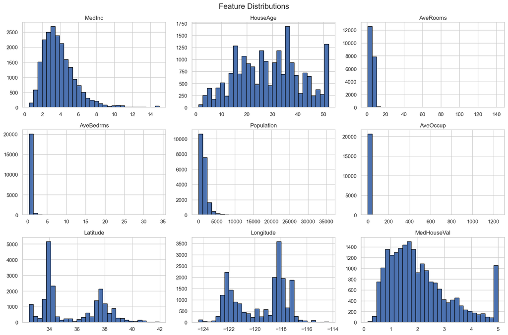

```python
df.hist(figsize=(15, 10), bins=30, edgecolor='black')
plt.suptitle("Feature Distributions", fontsize=16)
plt.tight_layout()
plt.show()
```

## 6. Correlation Analysis

A correlation heatmap helps identify relationships between features and the target variable.

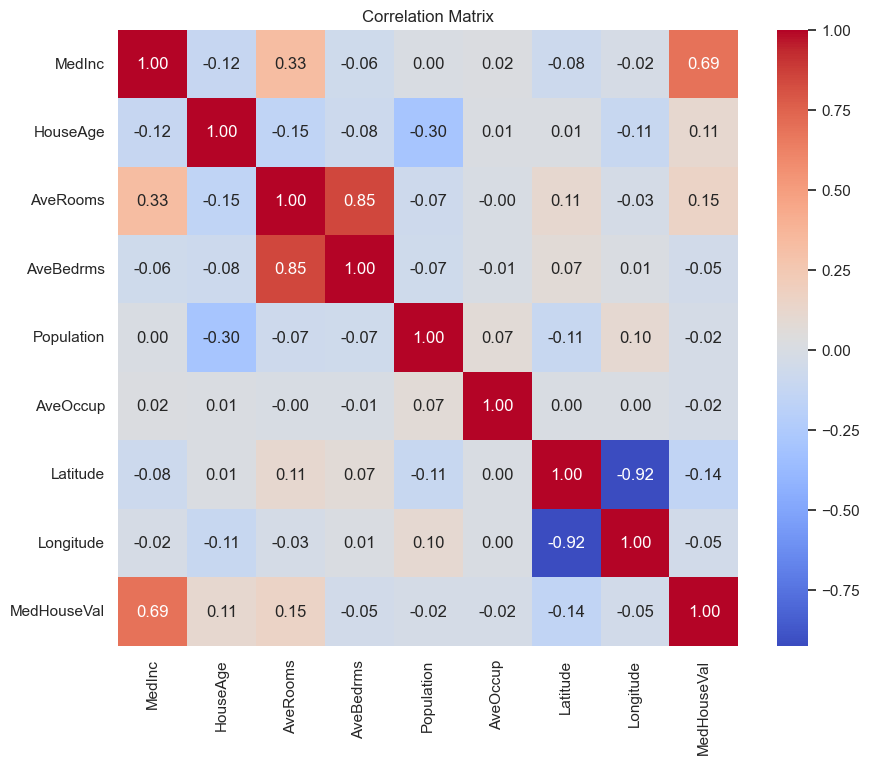

```python
plt.figure(figsize=(10, 8))
corr = df.corr()
sns.heatmap(corr, annot=True, cmap="coolwarm", fmt=".2f")
plt.title("Correlation Matrix")
plt.show()
```

## 7. Important Relationship: Median Income vs House Value

This scatter plot shows how median income relates to house prices.

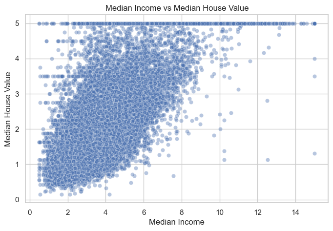

```python
plt.figure(figsize=(8, 5))
sns.scatterplot(x=df["MedInc"], y=df["MedHouseVal"], alpha=0.4)
plt.title("Median Income vs Median House Value")
plt.xlabel("Median Income")
plt.ylabel("Median House Value")
plt.show()
```

## 8. Define Features and Target

- Features (`X`) are all columns except the target.
- Target (`y`) is `MedHouseVal`.

```python
X = df.drop(columns="MedHouseVal")
y = df["MedHouseVal"]

print("Features shape:", X.shape)
print("Target shape:", y.shape)
```

```
Features shape: (20640, 8)
Target shape: (20640,)
```

## 9. Train-Test Split

We split the data into:

- 80% training data
- 20% testing data

This helps evaluate model performance on unseen data.

```python
X_train, X_test, y_train, y_test = train_test_split(
    X, y, test_size=0.2, random_state=42
)

print("X_train shape:", X_train.shape)
print("X_test shape:", X_test.shape)
print("y_train shape:", y_train.shape)
print("y_test shape:", y_test.shape)
```

```
X_train shape: (16512, 8)
X_test shape: (4128, 8)
y_train shape: (16512,)
y_test shape: (4128,)
```

## 10. Train the Linear Regression Model

We use the `LinearRegression` algorithm from scikit-learn to train the model.

```python
model = LinearRegression()
model.fit(X_train, y_train)

print("Model trained successfully!")
```

```
Model trained successfully!
```

## 11. Make Predictions

The trained model is used to predict house values on the test data.

```python
y_pred = model.predict(X_test)

print("First 10 predicted values:")
print(y_pred[:10])
```

```
First 10 predicted values:
[0.71912284 1.76401657 2.70965883 2.83892593 2.60465725 2.01175367
 2.64550005 2.16875532 2.74074644 3.91561473]
```

## 12. Model Evaluation

We evaluate the model using:

- **MAE**: Mean Absolute Error
- **RMSE**: Root Mean Squared Error
- **R² Score**: Goodness of fit

```python
mae = mean_absolute_error(y_test, y_pred)
mse = mean_squared_error(y_test, y_pred)
rmse = np.sqrt(mse)
r2 = r2_score(y_test, y_pred)

print(f"MAE  : {mae:.4f}")
print(f"MSE  : {mse:.4f}")
print(f"RMSE : {rmse:.4f}")
print(f"R²   : {r2:.4f}")
```

```
MAE  : 0.5332
MSE  : 0.5559
RMSE : 0.7456
R²   : 0.5758
```

## 13. Actual vs Predicted Values

This plot compares the actual house values with the predicted values.  
If predictions are perfect, the points will lie close to the red line.

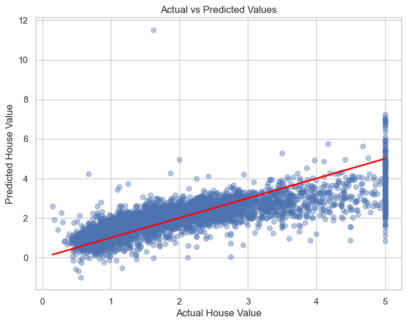

```python
plt.figure(figsize=(8, 6))
plt.scatter(y_test, y_pred, alpha=0.4)
plt.xlabel("Actual House Value")
plt.ylabel("Predicted House Value")
plt.title("Actual vs Predicted Values")

plt.plot(
    [y_test.min(), y_test.max()],
    [y_test.min(), y_test.max()],
    color="red",
    linewidth=2
)

plt.show()
```

## 14. Residual Analysis

Residuals are the differences between actual and predicted values.  
This plot helps us understand model errors.

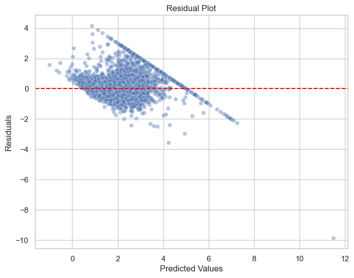

```python
residuals = y_test - y_pred

plt.figure(figsize=(8, 6))
sns.scatterplot(x=y_pred, y=residuals, alpha=0.4)
plt.axhline(y=0, color='red', linestyle='--')
plt.xlabel("Predicted Values")
plt.ylabel("Residuals")
plt.title("Residual Plot")
plt.show()
```

## 15. Feature Coefficients

The coefficients show how each feature influences the prediction in the linear regression model.

```python
coeff_df = pd.DataFrame({
    "Feature": X.columns,
    "Coefficient": model.coef_
})

coeff_df.sort_values(by="Coefficient", ascending=False)
```

|  | Feature | Coefficient |
| --- | --- | --- |
| 3 | AveBedrms | 0.783145 |
| 0 | MedInc | 0.448675 |
| 1 | HouseAge | 0.009724 |
| 4 | Population | -0.000002 |
| 5 | AveOccup | -0.003526 |
| 2 | AveRooms | -0.123323 |
| 6 | Latitude | -0.419792 |
| 7 | Longitude | -0.433708 |

## 16. Save the Trained Model

The trained model is saved as a `.pkl` file so it can be reused later without retraining.

```python
joblib.dump(model, "house_price_model.pkl")
print("Model saved as house_price_model.pkl")
```

```
Model saved as house_price_model.pkl
```

## 17. Conclusion

In this project, a Linear Regression model was built using the California Housing dataset.  
The dataset was explored through summary statistics, histograms, scatter plots, and a correlation heatmap.

After training and testing the model, performance was measured using MAE, RMSE, and R².  
The model provided a reasonable baseline for predicting house prices.

### Future Improvements

- Apply feature scaling
- Handle outliers
- Perform feature engineering
- Try advanced regression models such as Ridge, Lasso, Random Forest, or XGBoost